# Approaches to biomedical knowledge

## Likelihood Ratio Test: Intuition

Recall Bayes’ law:
$$P(A\mid B) = \frac{P(B\mid A)\cdot P(A)}{P(B)}
\tag{5}$$

- Suppose that Suppose that A is the presence (D+) or absence (D–) of a disease
- Suppose B represents the result of a diagnostic test (x) fulfils, say the test result being abnormal.
- Then

$$P(D^{+}\mid x=\mathrm{abn}) = \frac{P(x=\mathrm{abn}\mid D^{+})\cdot P(D^{+})}{P(x=\mathrm{abn})}
\tag{6}$$

## Likelihood Ratio Test: Intuition

- Similarly, the probability of the absence of the disease (D–) given the test result is
  $$\begin{align}
  P(D^{-}\mid x=\mathrm{abn}) &= 1 - P(D^{+}\mid x=\mathrm{abn}) \\
  &= \frac{P(x=\mathrm{abn}\mid D^{-})\cdot P(D^{-})}{P(x=\mathrm{abn})} \\
  \end{align}
  \tag{7}$$
- Dividing Equation 6 by Equation 7 and replacing P(D–) with 1 – P(D+) gives:
  $$\frac{P(D^{+}\mid x=\mathrm{abn}) }{1-P(D^{+}\mid x=\mathrm{abn}) } =
  \frac{P(x=\mathrm{abn}\mid D^{+})}{P(x=\mathrm{abn}\mid D^{-})}
  \times
  \frac{P(D^{+})}{1 - P(D^{+})}$$
- This is
  $$\text{Post-test odds of }D^{+} =
  \frac{P(x=\mathrm{abn}\mid D^{+})}{P(x=\mathrm{abn}\mid D^{-})}
  \times
  \text{Pre-test odds of }D^{+}$$
- This is the equation used in the Bayesian approach to interpret test results.
- The factor $\tfrac{P(x=\mathrm{abn}\mid D^{+})}{P(x=\mathrm{abn}\mid D^{-})}$ is termed the likelihood ratio (LR)
- When the test result equals to $r$, we write $LR(r)$.
- Generally speaking, the likelihood ratio indicates **how many times more (or less) likely a certain condition for a test result is expected to be observed in diseased, compared with non-diseased, people**

Habibzadeh F, Habibzadeh P (2019) [The likelihood ratio and its graphical representation. Biochem Med (Zagreb)](https://pubmed.ncbi.nlm.nih.gov/31015780/)

## Review: odds vs. probabilities

Odds and probability both describe uncertainty, and are related by the following equation

$$\text{odds} = \frac{P(\text{event})}{P(\text{not event})} = \frac{p}{1-p}
\tag{8}$$

- Equation 8 implies $p = \tfrac{\text{odds}}{1+\text{odds}}$
- **Probability**
  - Ranges from 0 to 1
- **Odds**
  - Ranges from 0 to $\infty$

| Probability | Odds | Reads as |
| --- | --- | --- |
| 50% | 1.00 | 1 : 1 |
| 90% | 9.00 | 9 : 1 |
| 2% | 0.0204 | ~1 : 49 |

- $p = 2\%$ → odds $= \dfrac{0.02}{1-0.02} \approx 0.0204$
- Small probabilities and their odds are nearly identical numerically; they diverge as $p \to 1$

## LIRICAL: motivation

- Current WES/WGS detection rate: $\sim 40-50\%$
- But prevailing algorithms don’t help us realize that there are no good candidates. #1 may still be poor.
- Some phenotypic features may support a diagnosis while others do not
- Prevailing algorithms don’t help users interpret the relative contribution of individual HPO terms to the computational ranking

[figure not shown]

[figure not shown]

## LIRICAL: Calculating the likelihood ratio

$$\rm{LR}=\dfrac{P(x|\mathcal{D})}{P(x|\neg \mathcal{D})}
\tag{9}$$

The definition of the LR can be extended to multiple tests. Suppose $X=(x_1,x_2,\cdots,x_n)$ is an array of $n$ test results. Under the assumption that the tests are independent, $\rm{LR}(X)$ is defined as:

$$\frac{{\rm{{Pr}}}(X|\mathcal{D})}{{\rm{Pr}}(X|\neg \mathcal{D})} = \frac{{\rm{Pr}}(x_1,x_2,\cdots,x_n|\mathcal{D})}{{\rm{{Pr}}}(x_1,x_2,\cdots,x_n|\neg \mathcal{D})}
= \prod_{i=1}^{n} \dfrac{{\rm{{Pr}}}(x_i|\mathcal{D})}{{\rm{Pr}}(x_i|\neg \mathcal{D})}
\tag{10}$$

- With this equation, one can calculate a likelihood ratio for a set of query HPO terms
- But how exactly do we calculate $\dfrac{P(x|\mathcal{D})}{P(x|\neg \mathcal{D})}$?

## $\dfrac{P(h_i|\mathcal{D})}{P(h_i|\neg \mathcal{D})}$

- Calculating $P(h_i|\mathcal{D})$, the probability of an individual with disease $D$ to have HPO term $h_i$, is easy
- If the HPO annotations for $D$ include the HPO term $h_i$, then $P(h_i|\mathcal{D})$ is equal to the frequency of that term in the HPO annotations for the disease

```bash
OMIM:614669 Auriculocondylar syndrome 2     HP:0000347  PMID:16114046   PCS     22/31       PHPO:skoehler[2012-10-17];HPO:probinson[2023-01-30]
```

- The above line is one of 285603 lines in the `phenotype.hpoa` file
- It specifies the frequency of Micrognathia HP:0000347 in individuals with *Auriculocondylar syndrome 2*
- It is less obvious how to specify $P(h_i|\neg \mathcal{D})$ - the frquency of $h_i$ in individuals without disease $D$.
- In principle, we could collect data on the general population, omitting individuals with $D$, and estimate the population prevalence of $h_i$
- This is both impossible and also not a good model of the diagnostic situation in medical genetics (individuals who present for diagnosis are not an unbiased selection from the general population)

## $P(h_i|\neg \mathcal{D})$

- LIRICAL therefore makes the assumption that every individual in the population has some Mendelian disease.
- Then we can estimate $P(h_i|\neg \mathcal{D})$ as follows (with a total of $N$ Mendelian diseases)
  $$P(h_i\mid D_j) = \frac{1}{N-1}\sum_{k\neq j} P(h_i\mid D_k) \approx \frac{1}{N}\sum_{k} f_{i}^{D_k}$$
- Here, $f_{i}^{D_k}$ is the frequency of HPO term $i$ in individuals with disease $k$
- This is the key assumption (“trick”) that allows us to apply the likelihood ratio framework to HPO-based differential diagnostic support
- There are many details about how to calculate $f_{i}^{D_k}$ in different situations and how to true-path rule is applied
- The next slide gives an impression of the algorithms.<sup>1</sup>
- LIRICAL also introduces an approach to estimate likelihood ratios for genotypes that we will not cover here.
[^5]: These details will not be covered in the exams

## LIRICAL: Calculating the likelihood ratio

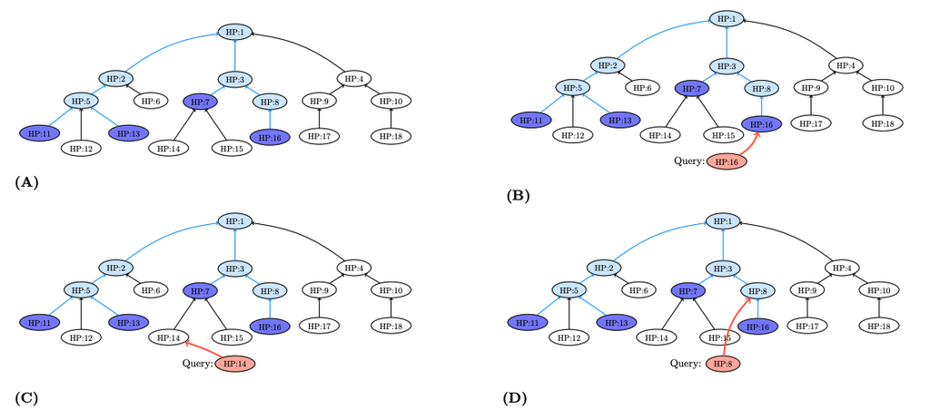

Calculating the likelihood ratios for phenotypes

HPO annotations and frequency data: used to calculate $\dfrac{P(x|\mathcal{D})}{P(x|\neg \mathcal{D})}$, with heuristics for non-exact matches.

- Disease model annotated with four HPO terms (dark blue), annotated are “inherited” by ancestors (light blue)
- Exact match to query term: $P(h_{16}|\mathcal{D})=f_{16}^{\mathcal{D}}$
- Query matches descendent of annotated term: $P(h_{14}|\mathcal{D})=\frac{f_{7}^{\mathcal{D}}}{2}=0.5$
- Query matches ancestor of annotated term: $P(h_{8}|\mathcal{D})=f_{16}^{\mathcal{D}}$

## LIRICAL: Posterior probabilities improve interpretation of rankings

[figure not shown]

- LIRICAL provides estimates of posttest probabilities

## LIRICAL: Performance on 384 published case reports

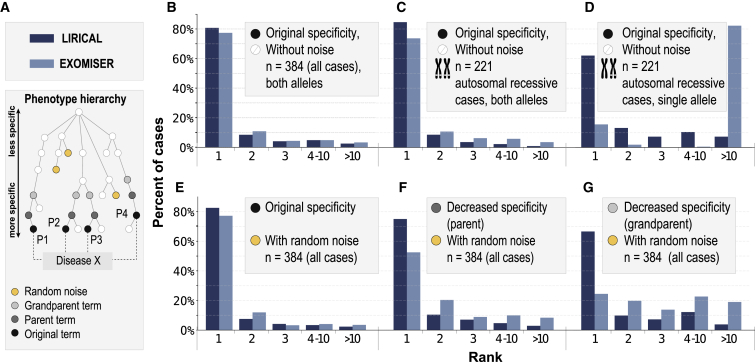

## LIRICAL: Detailed disease output page

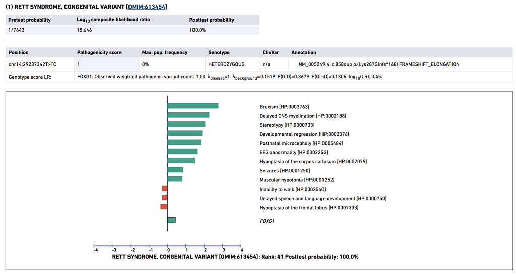

Robinson PN et al., Interpretable Clinical Genomics with a Likelihood Ratio Paradigm  
*Am J Hum Genet* 2020;**107**:403-417  
free for academic use

## Sources

- [Albert A (1982) On the use and computation of likelihood ratios in clinical chemistry. *Clin Chem* **28**:1113-9](https://pubmed.ncbi.nlm.nih.gov/7074890/): Excellent introduction to the mathemastics of LRs
- [Khinchin - Mathematical Foundations of Information Theory-Dover Publications (1957)](https://www.amazon.de/Mathematical-Foundations-Information-Advanced-Mathematics/dp/0486604349) Another excellent introduction to the mathemastics of LRs
- [Robinson PN et al. (2020) Interpretable Clinical Genomics with a Likelihood Ratio Paradigm. *Am J Hum Genet* **107**:403-417](https://pubmed.ncbi.nlm.nih.gov/32755546/)
- [Köhler S, et al. (2009) Clinical diagnostics in human genetics with semantic similarity searches in ontologies. *Am J Hum Genet* **85**:457-64](https://pubmed.ncbi.nlm.nih.gov/19800049/)